# Ford GoBike System Data Analysis and Visualizations

## by Bilal Almajnooni

## Investigation Overview

In this investigation, we will look at trends of trips, duration of trips, and as well as tendency of bikers on days of the week.

## Dataset Overview

This dataset includes bike rides data of 183,412 observations, and after cleaning it we were left with 168,639 observations. Its data members include:

- Trip time: which includes duration secs and mins, start time and end time, start hour and start day.
- Station info: which includes id, name, latitude, and longitude for both start and end stations.
- Bike info: which includes id.
- User info: which includes type(customer, subscriber), birth year, gender, age, and whether the user took the bike for the whole trip.

## Distribution of Trip Length For Bikers

Bikers tend to take short trips that ranges from 4 to 16 with an average of 10 minutes. The following graph x-axis is scaled to log

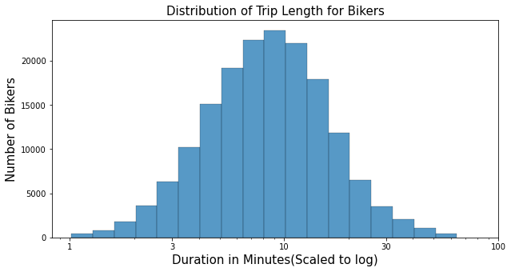

## Trip Length Per User Type

Only 90.7% of users are subscribers, and customers amount to 9.3% of the users. On average, customers tend to take longer trips than subscribers by 5 minutes.

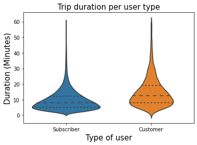

## Tendency of bikes to take same route of trip

There some occasions in which bikes that are used by users tend to take the same trip from start station to end station more than once and up to 7 times.

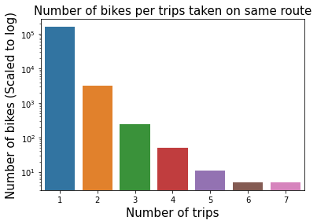

## Peak trip duration and age for bikers on each day of the week

On weekdays, users in their mid 30's tend use the bikes the most with an average duration of 7.5 minutes. However, during the weekends, users in their early 30's are more noticable in using the bikes to take a trip that lasts less than 7.5 minutes on average.

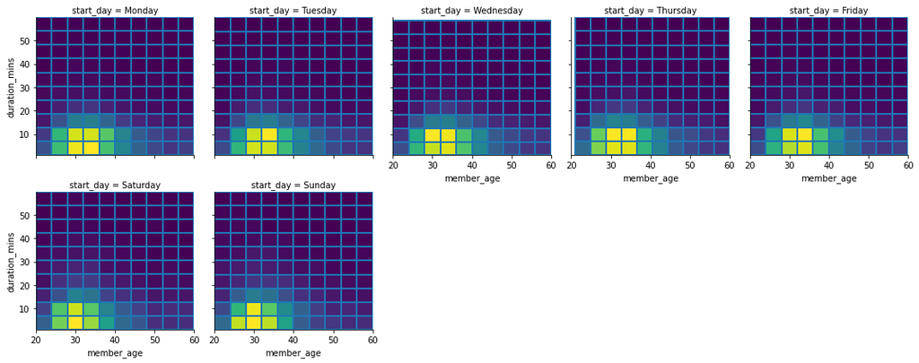